# Tutorial Principal Component Analysis and Regression: STATA, R and Python

### Python

In the original seatpos dataset, there exists strong multicollinearity problems. We can verify it from heatmap plot of the correlation matrix presented below. It is clear that including all covariates is ill advised considering the correlation between predictors. We can create a heatmap of correlation with the code below:

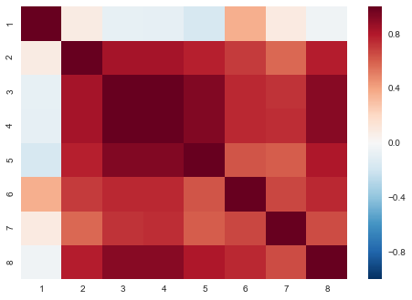

```r
# using the seaborn library to generate Heat map
import seaborn as sns;
sns.set()
cor_sp = df_sp.corr()
ax = sns.heatmap(cor_sp)
```

In order to reduce the number of predictors we can use PCA. Still we use the function sklearn.decomposition.PCA(n_components=None, copy=True, whiten=False) here.

Again, we use **PCA()** command.

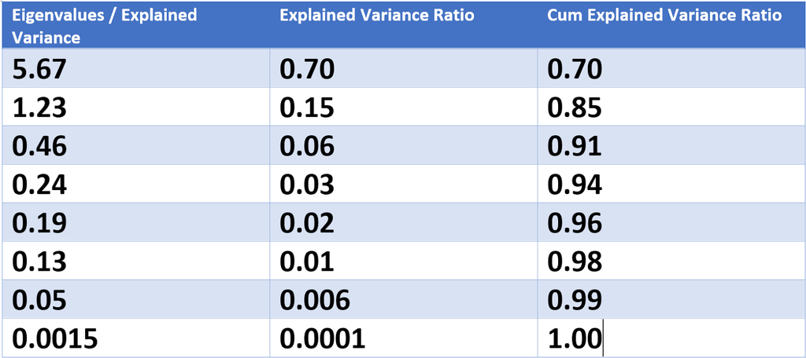

```r
# normalized the data for PCA
df_scaled = preprocessing.scale(df.iloc[:,range(1,8)])
df_sp = df.iloc[:,range(1,8)]
# using sklearn.decomposition.PCA to conduct PCA to the data
pca = PCA()
pca.fit(df_sp)
# show the results
pca.components_
pca.explained_variance_
pca.explained_variance_ratio_
np.cumsum(pca.explained_variance_ratio_)
```

This information can be summarized graphically using the same commands demonstrated in the first example. Specifically, we can plot the components corresponding eigenvalues and the cumulative variation explained by each component.

[figure not shown]

```r
# generate the Scree plot for PCs
fig = plt.figure(figsize=(8,5))
sing_vals = np.arange(4) + 1
plt.plot(sing_vals, np.cumsum(pca.explained_variance_ratio_), linewidth=2)
plt.title(' cumulative variation  Plot')
plt.xlabel('Principal Component')
plt.ylabel(' cumulative variation ')
plt.show()
```

Using this information we can build a normal linear regression model where we replace the predictor with the principal component. For example, considering that the first principal component explains over 70 percent of the variation in the predictors, we might interested in fitting the model $hipcenter = \beta_0 + \beta_1pc1$

In Python, we construct the linear model using **linear_model.LinearRegression** function. We build the linear model with PC1 as the single predictor and hipcenter as the response variable. Below is the code to achieve this in Python:

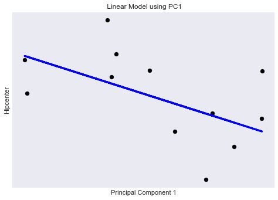

```r
#using sklearn.linear_model
from sklearn import linear_model
# Split the data into training/testing sets
X_train = X[:25]
X_test = X[26:]
# Split the targets into training/testing sets
y_train = response[:25]
y_test = response[26:]
# Create linear regression object
regr = linear_model.LinearRegression()
# Train the model using the training sets
regr.fit(X_train, y_train)
# Make predictions using the testing set
y_pred = regr.predict(X_test)
# The coefficients
print('Coefficients: \n', regr.coef_)
# The mean squared error
print("Mean squared error: %.2f"
      % mean_squared_error(y_test, y_pred))
# Explained variance score: 1 is perfect prediction
print('Variance score: %.2f' % r2_score(y_test, y_pred))
# Plot outputs
plt.scatter(X_test, y_test,  color='black')
plt.plot(X_test, y_pred, color='blue', linewidth=3)
plt.show()
```

Considering we are interested in a predictive model, we must see how the model performs with out of sample observations. This can be achieved using k cross-validations. In this procedure, we divide the data into K folds. K-1 folds are used to train the model and then 1 fold is used to test the model. We measure the RMSE as our out of sample prediction error.

In Python, cross validation can be done with **Kfold**

```r
# using the sklearn.cross_validation library to conduct CV
from sklearn.cross_validation import KFold
# generate 10 fold CV dataset
kf = KFold(len(X), n_folds=10)
xval_err = 0

linreg = linear_model.LinearRegression()
# Conducting 10 fold cross-validations
for train,test in kf:
    linreg.fit(X.iloc[train,], response.iloc[train,])
    p = linreg.predict(X.iloc[test,])
    e = p-response.iloc[test,]
    xval_err += np.dot(e,e)

# calculate the average error rate based on 10 fold CV results
rmse_10cv = np.sqrt(xval_err/len(X))
print('RMSE on 10-fold CV: %.4f' %rmse_10cv)
```

In this case, we will compute the estimated RMSE for a model with only pc1 as a predictor with k=10. Then, we will repeat the process with pc1 and pc2 as predictors and continue with the process until RMSE does not decrease significantly.

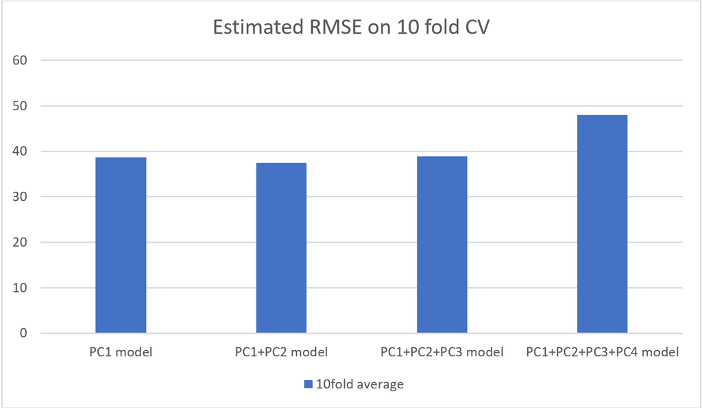

## References

Braun, John. (2013). “Chapter 10: Principal Components Analysis (PCA).” Retrieved from: http://www.stats.uwo.ca/faculty/braun/ss3850/notes/sas10.pdf

Hooker, Giles. (2008). “BTRY: Applied Functional Data Analysis: Functional Principal Component Regression.” Retrieved from: http://faculty.bscb.cornell.edu/~hooker/FDA2008/Lecture13_handout.pdf

Faculty Microcomputer Resource Center. (2014). “Help for crossfold .” Retrieved from: http://fmwww.bc.edu/repec/bocode/c/crossfold.html

Faraway, J. (2016). “Linear Models with R.” CRC Press

Gutierrez-Osuna, Ricardo. (2017). “Lecture 13: Validation.” Intelligent Senson Systems“. Retrieved from: http://research.cs.tamu.edu/prism/lectures/iss/iss_l13.pdf

Statistics How to. (2017).“Kaiser-Meyer-Olkin (KMO) Test for Sampling Adequacy.” Retrieved from: http://www.statisticshowto.com/kaiser-meyer-olkin/

Social Science Computing Cooperative. (2017).“Finding and Installing User-Written Stata Programs” Retrieved from: https://www.ssc.wisc.edu/sscc/pubs/4-16.htm

Statistical tools for high-throughput data analysis. (2017). “Principal Component Analysis in R: prcomp vs princomp” Retrieved from http://www.sthda.com/english/articles/31-principal-component-methods-in-r-practical-guide/118-principal-component-analysis-in-r-prcomp-vs-princomp/

University of Michigan (2017). “Applied Machine Learning in Python” Retrived from: https://www.coursera.org/learn/python-machine-learning/lecture/Vm0Ie/cross-validation

StatckExchange. (2017). “Interpretation of biplots in principal components analysis.” Retrieved from: https://stats.stackexchange.com/questions/2038/interpretation-of-biplots-in-principal-components-analysis